# Your Digest for Saturday, Oct 14, 2023 11:59 PM

#2020BSQ-JUL/Q42

# Immune response to viral infection

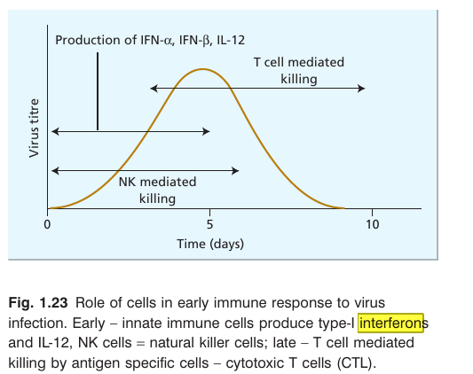

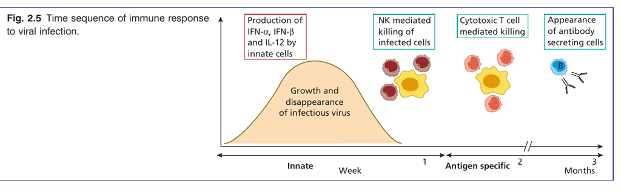

Interferons help to control the initial infection.

> [!INFO] The main cytokines  
> The main immune cytokines are
> - Interferons : 3 interferons with defined roles.
> - interleukins - about 40;

## Interferons

#2020BSQ-JUL/Q42

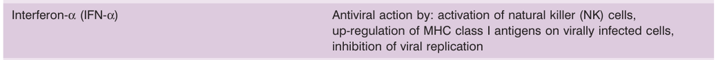

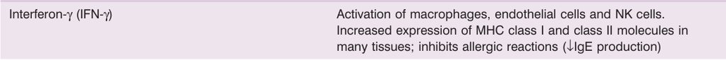

- Interferons also have anti cancer effects

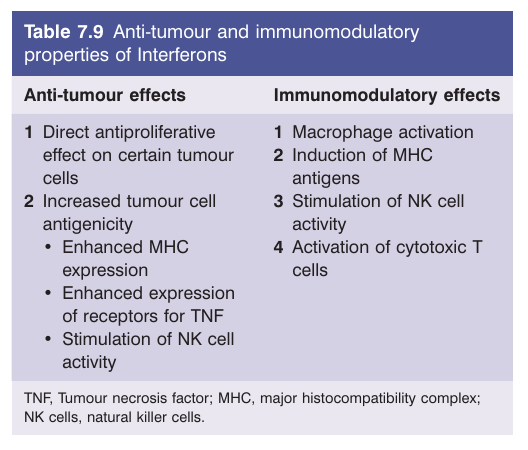

# Genetic anticipation

#2020BSQ-JUL/Q40  
[Source](https://medlineplus.gov/genetics/understanding/inheritance/anticipation/)  
Refers to the appearance of signs and symptoms of a disease progressively earlier and earlier in successive generations.  
Typical of diseases caused by a trinucleotide repeat.  
These are sequences of 3 nucleotides which repeat. *The number of repeats can increase from one generation to the next*, *making the DNA more and more unstable*. Accumulation of these repeats is called *trinucleotide repeat expansion.*  
Examples:

1. Huntington's chorea
2. Fragile X - the commonest form of autism of *known cause*.
3. Myotonic dystrophy
4. Spinocerebellar ataxia type 1
5. [[General medicine 6-Neurology#Muscular dystrophies and myotonia|Spinal Muscular atrophy]] and bulbar muscular atrophy
6. FRAXE mental retardation

# Patterns of inheritance

| Inheritance Pattern | Characteristics | Disease Examples |
| --- | --- | --- |
| Autosomal Dominant | Each affected person usually has an affected parent; occurs in ❗every generation | Huntington’s disease, neurofibromatosis, achondroplasia, familial hypercholesterolemia |
| Autosomal Recessive | Both parents of an affected person are carriers; ❗not typically seen in every generation | Tay-Sachs disease, sickle cell anemia, cystic fibrosis, phenylketonuria (PKU) |
| X-linked Dominant | ❗Females are more frequently affected because all daughters and no sons of an affected man will be affected; can have ❗affected males and ❗females in same generation if the mother is affected | Hypophatemic rickets (vitamin Dresistant rickets), ornithine transcarbamylase deficiency |
| X-linked Recessive | ❗Males are more frequently affected; affected males often present in each generation | Hemophilia A, Duchenne muscular dystrophy |
| Mitochondrial | Can ❗affect both males and females, but ❗❗only passed on by females because all mitochondria of all children come from the mother; can appear in every generation | Leber’s hereditary optic neuropathy, Kearns-Sayre syndrome |

# The optic nerve

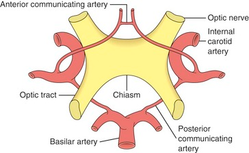

> At the chiasm, decussating axons from the superior-nasal retina travel posteriorly within the chiasm, while those originating from the inferior-nasal retina travel anteriorly.

> Mnemonic: inferior anterior, superior posterior. (role reversal)

## Junctional scotoma

Lesions of the optic chiasm (OC) typically produce bitemporal hemianopia (BTH) on visual field (VF) testing, whereas lesions located at the nasal optic nerve-chiasmal (ON-OC) junction have been proposed to produce junctional scotoma (JXS), a central defect in the ipsilateral eye with temporal field loss in the contralateral eye.[Source](https://pubmed.ncbi.nlm.nih.gov/34417771/)  
Understanding visual field defects due to lesions of the optic chiasm is very difficult. :/  
Easiest course of action is to resort to wikipedia:

- Complete optic chiasmal lesions -> bitemporal hemianopia
- Anterior chiasmal syndrome -> *Central scotoma* in one eye and temporal hemianopia in the other eye
- Middle chiasmal syndrome -> bitemporal hemianopia
- Posterior chiasmal -> paracentral bitemporal field defects
- Lateral chiasmal lesions -> binasal hemianopia
- Lesions at the junction of the optic nerve and chiasm may produce an ipsilateral monocular temporal scotoma known as 'junctional scotoma'

**Argyll-robertson** (argyll robertson) pupil is a high specific manifestation of late neurosyphillis. *The pupil constricts during accomodation but **does not constrict in response to light***. Mechanism isn't known. Probably due to

> dorsal midbrain lesion that interrupts the pupillary light reflex pathway but spares the more ventral pupillary near the reflex pathway.[Source](https://www.ncbi.nlm.nih.gov/books/NBK537179/)  
> This is called *light-near dissoaciation*.

light-near dissociation is also seen in **Adie's tonic pupil**, an idiopathic lesion.

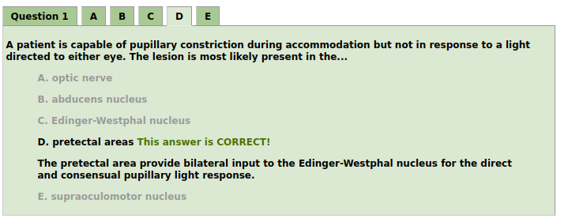

This answer on quora actually does the best job of explaining why the ophthalmic nerve isn't required for the accomodation reflex:

1. It can be under voluntary control
2. The opthalmic nerve from the other eye can serve as the afferent limb.

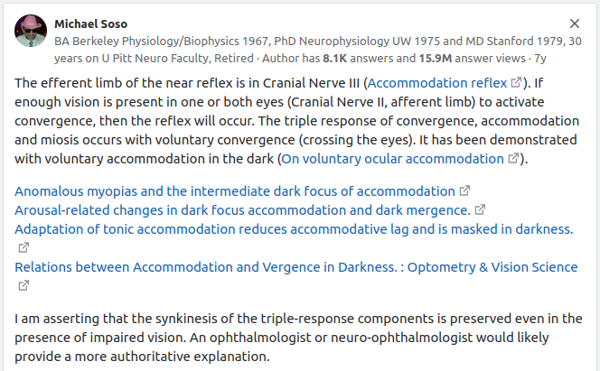

   [Source](https://www.quora.com/Why-does-near-reflex-is-preserved-in-optic-nerve-lesions)

#2021BSQ-JUL/Q34  
#2020BSQ-JUL/Q39

### MERRF

Myoclonic epilepsy with ragged red fibers (MERRF) is **a multisystem mitochondrial syndrome characterized by progressive myoclonus and seizures**

### NARP

In summary, NARP is **a mitochondrial disorder that is characterized by N+europathy, A+taxia, and R+etinitis pigmentosa**.

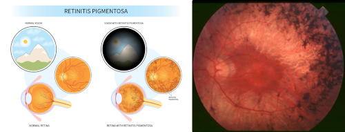

> a chronic hereditary eye disease characterized by black pigmentation and gradual degeneration of the retina.

#2020BSQ-JUL/Q41

> [!WARNING] Leishmaniasis is a notifiable disease in Sri Lanka as of 2008

[figure not shown]

## Leishmaniasis in Sri Lanka

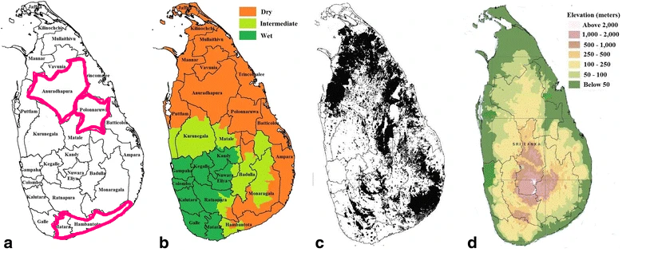

> [!TIP] Leishmaniasis in Sri Lanka  
> DCOSL -> Donovani, cutaneous, in Sri Lanka

[figure not shown]

> [Source](https://parasitesandvectors.biomedcentral.com/articles/10.1186/s13071-018-2647-5)

In SL, leishmaniasis is reported mainly in Anuradphapura, polonnaruwa, hambantota and Matara. The disease was began spreading locally in the 1990s. Incidence has been increasing rapidly in the past decade.

> **Sri lanka is endemic for Leishmaniasis caused by *Leishmania donovani***.

In SL, Leishmania donovani (usually associated with visceral leshmaniasis (VL)) is causes *cutaneous* leishmaniasis (CL). This is termed *dermotropism*. However, it can case VL as well.  
**Phelbotomus argentipes** is the main vector in SL although others are also present.  
In SL, Leishmania incidence is seasonal.

## Leishmaniasis has a wide spectrum of disease.

## Diffuse cutaneous

> Diffuse cutaneous leishmaniasis — is a **rare syndrome** that occurs mainly in the setting of *L.L. aethiopica*, *L.L. mexicana*, and *L.L. amazonensis* infection.  
> It begins as a localized lesion **that does not ulcerate**; rather, amastigotes disseminate to macrophages in other areas of the skin. People who develop DCL usually have a defect in cell mediated immunity.

## Musocal leishmaniasis

AKA espundia.  
Mainly occurs in the 'new world'. (i.e North and south America).  
So the causative parasites are L brazilliensis, guyanensis, panamensis, amazonensis,

- Main *reservoir* in Asia is *dogs and foxes*.

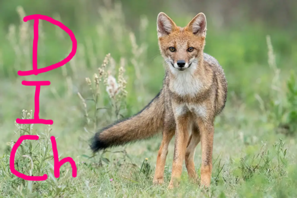

- Untreated, the disease will progress to cause *pancytopaenia* and *immunosuppresion* leading to **death in a year by superadded bacterial infection**.
- **Diagnosis:** Identification of the organisms in aspirate of *bone marrow* or *liver or spleen*.
- **Treatment:** pentavalent antimony salts (Sodium **stibogluconate** / melumine **antimoniate**) OR IV **amphotericin** B and IM **paromomycin**. Some patients develop post kalar-azar dermal leishmaniasis.

### Post kala-azar dermal leishmaniasis (PKDL)

Cannot culture. Serology is used for diagnosis.  
Treatment is with **doxycycline**.

[output not shown]

#### Parietal lobe dysfunction features

#2020BSQ-JUL/Q56  
The parietal lobe syndrome consists of

1. constructional apraxia,
2. visuospatial agnosia,
3. topographical disorientation (getting lost, inability to learn new routes),
4. visual inattention and
5. cortical sensory loss, when objects can be felt but not fully interpreted or discriminated.

(Tay-sach's)  
A #autosomal-Recessive defect in hexosaminidase which causes accumulation of lipids within cells. Particularly affects CNS neurons. Affected *children* develop *normally until about 6 months of age and* then show *cognitive decline with loss of milestones*, dementia, blindness and *cherry red spots* in the eyes.

#2020BSQ-JUL/Q32

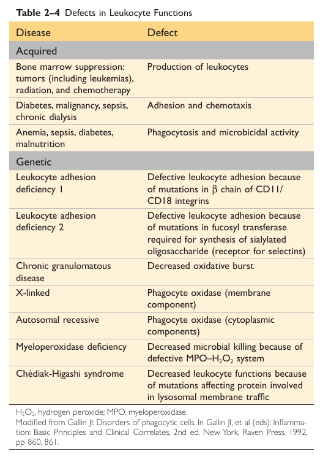

```
- Defective *phagolysosome fusion*. (large lysosome vesicles are seen within the neutrophils)
```

Pathogenesis:  
Urate is a product of *purine* metabolism.  
It is eliminated by the kidney and this is regulated by resorptive proteins.

> [!INFO] Note the drugs!  
> Thiazides and low dose aspirin can increase urate levels.

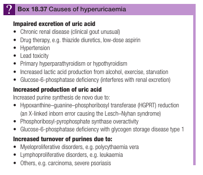

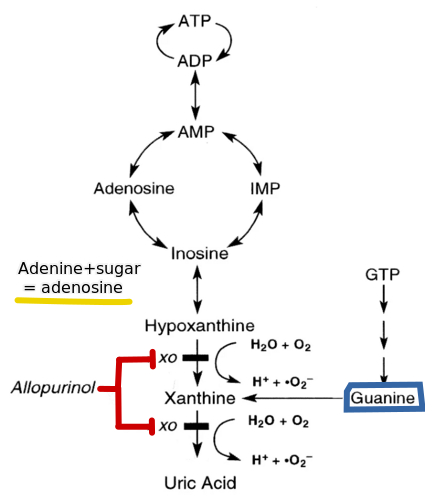

Decreased GFR (like in CKD) decreases urate elimination -> predisposes to gout.

```
- **Valproate** is good for almost everything, including absence, myotonic, myoclonic, partial, secondary generalized.
```

However, clonazepam is used to achieve rapid control of epilepsy. (eg. When a patient with frequent seizures presents for the first time).